# TP — Neural ODE de vieillissement : d'un véhicule à une flotte

## Comparaison finale : capacité et résistance

On compare maintenant sur les **deux véhicules de test E et F** :

- la vraie trajectoire avec mémoire ;
- le modèle sans mémoire ;
- le modèle qui reçoit explicitement $h$.

On affiche séparément :

$$ C_{\max}(t) $$

pour voir clairement la **chute de capacité**, puis une résistance ramenée aux mêmes conditions de référence :

$$ R_{0,\mathrm{ref}}(t) = R_0(SOC=0.5,T=25^\circ C) \left(1+D_R(t)\right) $$

pour voir clairement l'**augmentation de résistance** sans que les variations instantanées de $SOC$ et $T$ ne masquent la tendance.

```python
memory_test_results = {}

for v_np, v_j in zip(
    memory_test_fleet,
    memory_test_fleet_j,
):
    out_mem = np.asarray(
        simulate_vehicle_with_memory(
            memory_model,
            v_j,
        )
    )

    U_mem = out_mem[:, 0]
    C_mem = out_mem[:, 2]
    DR_mem = out_mem[:, 5]

    no_mem = (
        no_memory_test_results[
            v_np["vehicle_id"]
        ]
    )

    rmse_U_nm = np.sqrt(
        np.mean(
            (
                no_mem["U"]
                - v_np["U"]
            )**2
        )
    )

    rmse_U_mem = np.sqrt(
        np.mean(
            (
                U_mem
                - v_np["U"]
            )**2
        )
    )

    memory_test_results[
        v_np["vehicle_id"]
    ] = {
        "U_mem": U_mem,
        "C_mem": C_mem,
        "DR_mem": DR_mem,
        "rmse_nm": rmse_U_nm,
        "rmse_mem": rmse_U_mem,
    }

    print(
        f"Véhicule "
        f"{v_np['vehicle_id']} | "
        f"RMSE sans mémoire="
        f"{rmse_U_nm:.4f} V | "
        f"RMSE avec mémoire="
        f"{rmse_U_mem:.4f} V"
    )

    print(
        "   Erreur Cmax finale "
        "sans / avec mémoire :",
        f"{no_mem['C'][-1] - v_np['C'][-1]:+.2f}",
        "/",
        f"{C_mem[-1] - v_np['C'][-1]:+.2f}",
        "Ah",
    )

    print(
        "   Erreur D_R finale "
        "sans / avec mémoire :",
        f"{no_mem['DR'][-1] - v_np['D_R'][-1]:+.4f}",
        "/",
        f"{DR_mem[-1] - v_np['D_R'][-1]:+.4f}",
    )
```

```
Véhicule E | RMSE sans mémoire=1.6478 V | RMSE avec mémoire=1.4815 V
   Erreur Cmax finale sans / avec mémoire : +5.90 / +5.30 Ah
   Erreur D_R finale sans / avec mémoire : -0.0403 / -0.0347
Véhicule F | RMSE sans mémoire=2.4768 V | RMSE avec mémoire=0.8384 V
   Erreur Cmax finale sans / avec mémoire : -5.88 / -3.42 Ah
   Erreur D_R finale sans / avec mémoire : +0.0806 / +0.0258
```

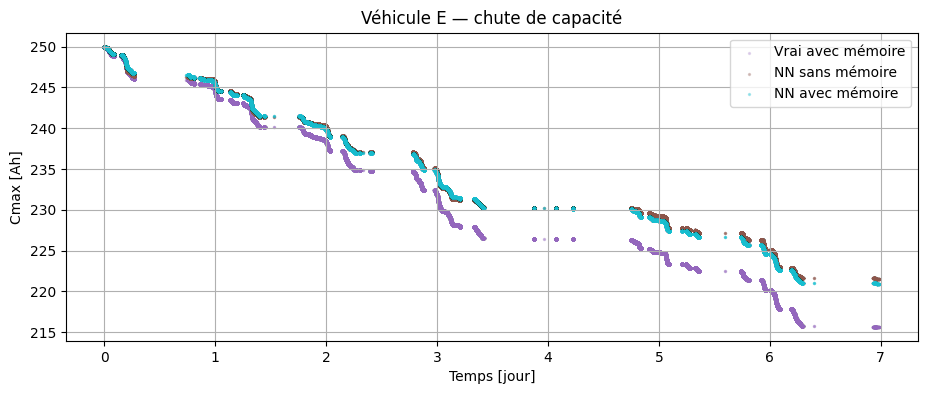

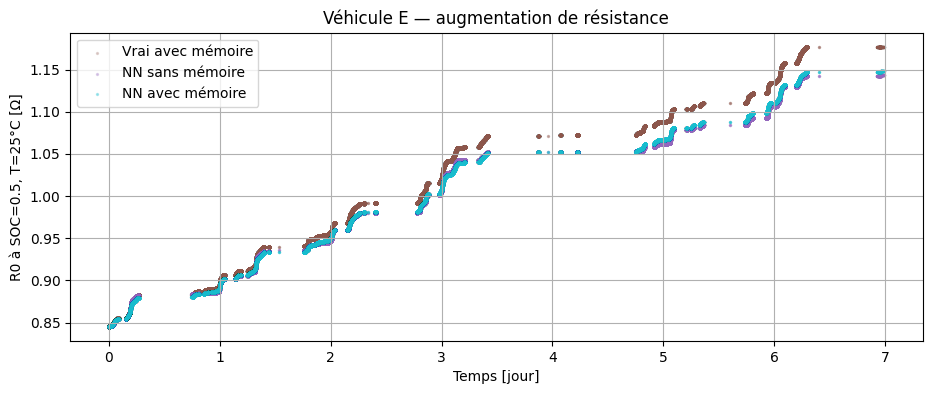

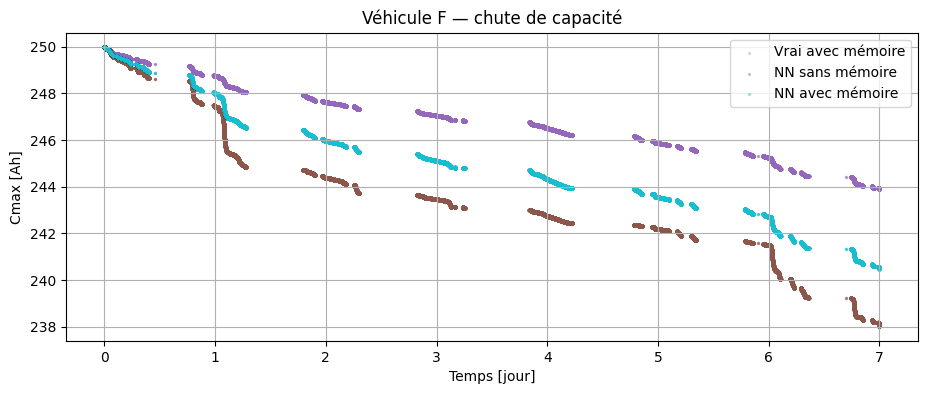

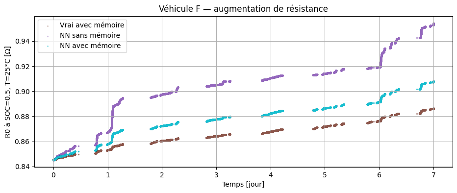

```python
R0_REF_BOL = float(
    R0_base_np(
        0.5,
        25.0,
    )
)

for v in memory_test_fleet:
    vehicle_id = (
        v["vehicle_id"]
    )

    no_mem = (
        no_memory_test_results[
            vehicle_id
        ]
    )

    with_mem = (
        memory_test_results[
            vehicle_id
        ]
    )

    # ========================================================
    # 1. CHUTE DE CAPACITÉ
    # ========================================================

    fig = plt.figure(
        figsize=(11, 4)
    )

    plt.scatter(
        v["t"] / 86400,
        v["C"],
        s=SCATTER_SIZE,
        alpha=0.22,
        color=COLOR_C,
        label="Vrai avec mémoire",
        rasterized=True,
    )

    plt.scatter(
        v["t"] / 86400,
        no_mem["C"],
        s=SCATTER_SIZE,
        alpha=0.28,
        color=COLOR_DAMAGE,
        label="NN sans mémoire",
        rasterized=True,
    )

    plt.scatter(
        v["t"] / 86400,
        with_mem["C_mem"],
        s=SCATTER_SIZE,
        alpha=0.32,
        color=COLOR_PRED,
        label="NN avec mémoire",
        rasterized=True,
    )

    plt.xlabel("Temps [jour]")
    plt.ylabel("Cmax [Ah]")

    plt.title(
        f"Véhicule {vehicle_id} — "
        "chute de capacité"
    )

    plt.legend()
    plt.grid(True)
    plt.show()

    # ========================================================
    # 2. AUGMENTATION DE RÉSISTANCE
    # ========================================================

    R0_ref_true = (
        R0_REF_BOL
        * (
            1.0
            + v["D_R"]
        )
    )

    R0_ref_no_mem = (
        R0_REF_BOL
        * (
            1.0
            + no_mem["DR"]
        )
    )

    R0_ref_with_mem = (
        R0_REF_BOL
        * (
            1.0
            + with_mem["DR_mem"]
        )
    )

    fig = plt.figure(
        figsize=(11, 4)
    )

    plt.scatter(
        v["t"] / 86400,
        R0_ref_true,
        s=SCATTER_SIZE,
        alpha=0.22,
        color=COLOR_DAMAGE,
        label="Vrai avec mémoire",
        rasterized=True,
    )

    plt.scatter(
        v["t"] / 86400,
        R0_ref_no_mem,
        s=SCATTER_SIZE,
        alpha=0.28,
        color=COLOR_C,
        label="NN sans mémoire",
        rasterized=True,
    )

    plt.scatter(
        v["t"] / 86400,
        R0_ref_with_mem,
        s=SCATTER_SIZE,
        alpha=0.32,
        color=COLOR_PRED,
        label="NN avec mémoire",
        rasterized=True,
    )

    plt.xlabel("Temps [jour]")
    plt.ylabel(
        "R0 à SOC=0.5, T=25°C [Ω]"
    )

    plt.title(
        f"Véhicule {vehicle_id} — "
        "augmentation de résistance"
    )

    plt.legend()
    plt.grid(True)
    plt.show()
```

## Ce que montre cette expérience

Le modèle sans mémoire apprend essentiellement une moyenne :

$$ f_\theta(SOC,T,I) \approx \mathbb E \left[ f(SOC,T,I,h) \mid SOC,T,I \right]. $$

Lorsque l'historique du véhicule est atypique, cette information manque.

Le modèle qui reçoit $h$ retrouve une dynamique de type :

$$ \boxed{ \frac{dD}{dQ} = f_\theta(SOC,T,I,h). } $$

L'étape suivante serait de ne plus imposer $h$, mais de l'apprendre à partir de l'historique :

$$ \boxed{ dh_t = g_\phi(h_t)\,dX_t. } $$

C'est l'ouverture naturelle vers une Neural CDE.

## Questions

1. Pourquoi avoir choisi une loi affine aussi simple en $SOC$, $T$ et $I$ ?
2. Pourquoi le courant intervient-il à la fois dans $dQ$ et dans la loi de stress ?
3. Quel schéma numérique est utilisé pour intégrer la Neural ODE ?
4. Quel est le rôle de `jax.lax.scan` ?
5. Pourquoi les Véhicules E et F sont-ils de vrais tests dans ce TP ?
6. Pourquoi ramener $R_0$ à $SOC=0.5$ et $T=25^\circ C$ pour visualiser son vieillissement ?
7. Pourquoi un modèle sans mémoire peut-il être correct en moyenne mais mauvais sur certains véhicules ?
8. Comment réutiliser les poids sauvegardés pour retrouver une loi explicite dans le TP suivant ?